# 2_Enhanced_Visualization

Min-Yao

2025-09-30

## Table of Contents

1. Create an Enhanced Dimensional Reduction Plot
2. Generate a Heatmap Plot
3. Create Enhanced Dot Plots (New in v1.1.0)
4. Create an Enhanced Violin Plot
5. Visualize Cluster Distribution in Samples
6. Generate a Waterfall Plot
7. Create Volcano Plots (New in v1.1.0)
8. Explore Color Functions

## Create an Enhanced Dimensional Reduction Plot

```r
library(Seurat)
library(SeuratExtend)
set.seed(2025)
```

```r
pbmc <- readRDS("./output/pbmc3k_final.rds")
```

```r
pbmc$cluster <- Idents(pbmc)
```

### Introduction

In Seurat, dimension reduction plots such as UMAP are typically created using `DimPlot` for discrete variables and `FeaturePlot` for continuous variables. `SeuratExtend` simplifies this process with `DimPlot2`, which automatically handles both types of variables without requiring different functions. The function retains most of the usage conventions of both `DimPlot` and `FeaturePlot` while introducing numerous additional parameters for enhanced customization.

### Basic Usage

To generate a basic dimension reduction plot, simply call `DimPlot2` with your Seurat object:

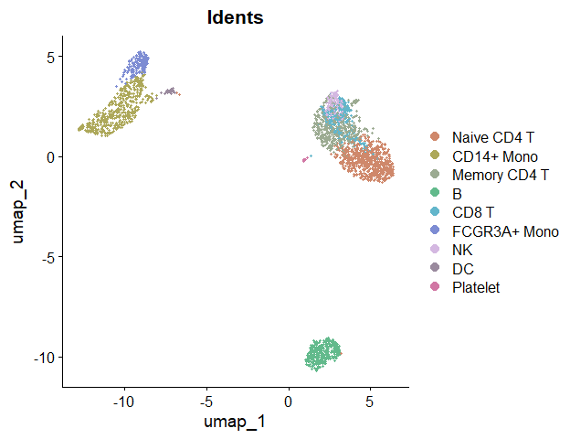

```r
DimPlot2(pbmc)
```

### Visualizing Different Variables

`DimPlot2` can handle both discrete and continuous variables seamlessly. Here’s how to input different variables into the plot:

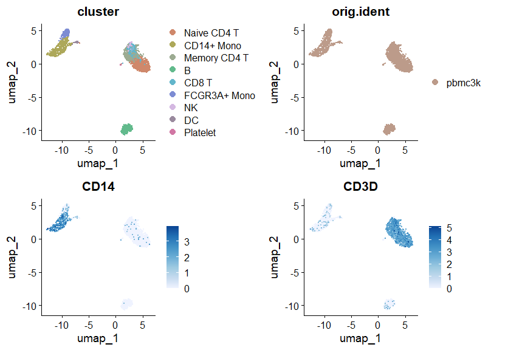

```r
DimPlot2(pbmc, features = c("cluster", "orig.ident", "CD14", "CD3D"))
```

**Note**: Starting from v1.1.0, the default color scheme for continuous variables has changed from viridis “A” to RColorBrewer “Blues”. This change was made because the previous viridis-A series used black for low expression and red-yellow for high expression, which could be visually problematic - black tends to be too eye-catching while yellow can be hard to see against a white background. The new default uses light blue for low expression and deep blue for high expression, providing better visual clarity. If you prefer the previous color scheme, simply set `cols = "A"` in your function call.

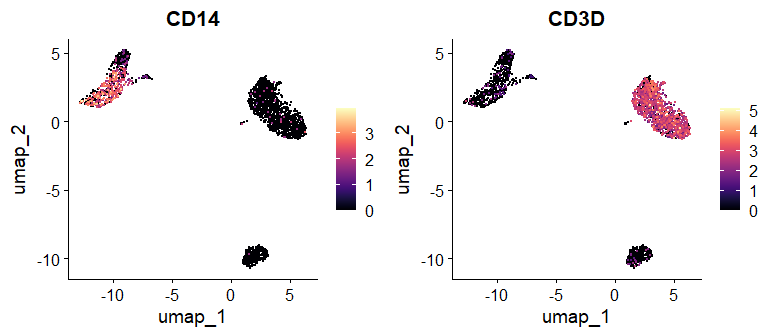

```r
DimPlot2(pbmc, features = c("CD14", "CD3D"), cols = "A")
```

### Splitting by Variable

You can split the visualization by a specific variable, which is particularly useful for comparative analysis across conditions or identities:

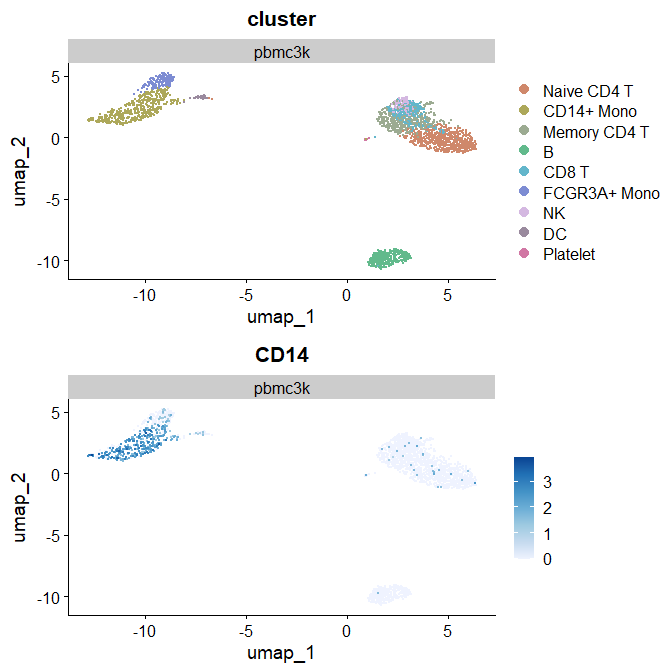

```r
DimPlot2(pbmc, features = c("cluster", "CD14"), split.by = "orig.ident", ncol = 1)
```

### Highlighting Specific Cells

To highlight cells of interest, such as a specific cluster, you can define the cells explicitly and use them in your plot:

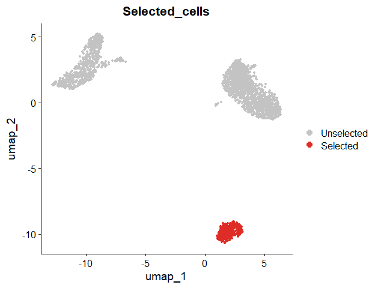

```r
b_cells <- colnames(pbmc)[pbmc$cluster == "B"]
DimPlot2(pbmc, cells.highlight = b_cells)
```

### Advanced Customization

For each variable, you can specify custom colors and adjust themes. For detailed information on color customization, refer to the Explore Color Functions section:

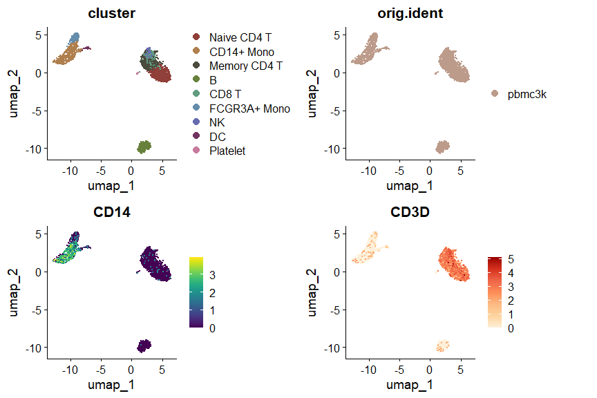

```r
DimPlot2(
  pbmc,
  features = c("cluster", "orig.ident", "CD14", "CD3D"),
  cols = list(
    "cluster" = "default", # dark theme
    "CD14" = "D",
    "CD3D" = "OrRd"
  ))
```

### Adding Labels and Boxes

To further enhance the plot, you can add labels and bounding boxes to clearly delineate different groups or points of interest:

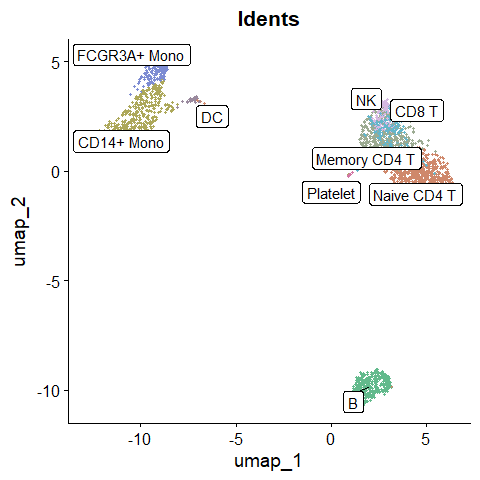

```r
DimPlot2(pbmc, label = TRUE, box = TRUE, label.color = "black", repel = TRUE, theme = NoLegend())
```

### Simplifying Labels with Indices

For plots with lengthy cluster names, you can use indices to create cleaner visualizations:

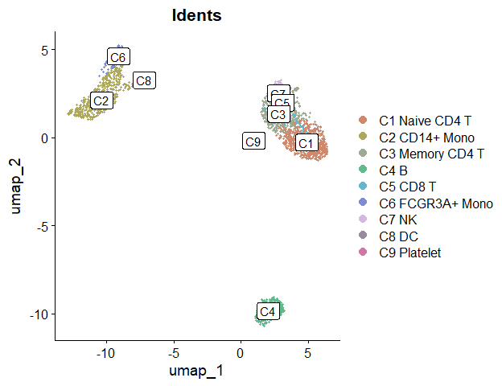

```r
DimPlot2(pbmc, index.title = "C", box = TRUE, label.color = "black")
```

### Adding UMAP Arrows (New in v1.1.0)

Starting from v1.1.0, you can add simplified axis indicators to your dimension reduction plots using the `theme_umap_arrows` function. This is particularly useful for UMAP or t-SNE plots where traditional axes are often removed to reduce visual clutter:

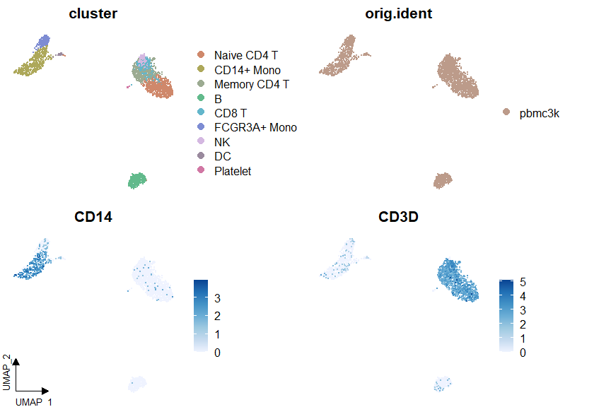

```r
# Add simplified axis indicators
DimPlot2(
  pbmc,
  features = c("cluster", "orig.ident", "CD14", "CD3D"),
  theme = NoAxes()
) + theme_umap_arrows()
```

The `theme_umap_arrows` function provides several parameters for customization:

- `anchor_x/y`: Position of the arrow origin
- `line_length`: Length of the arrow lines
- `arrow_length`: Size of arrowheads
- `text_offset_x/y`: Position of axis labels
- `text_size`: Font size for labels
- `line_width`: Width of arrow lines
- `x_label/y_label`: Custom axis labels

### Multiple Feature Visualization

When visualizing multiple features simultaneously, you might want to add arrows to each subplot:

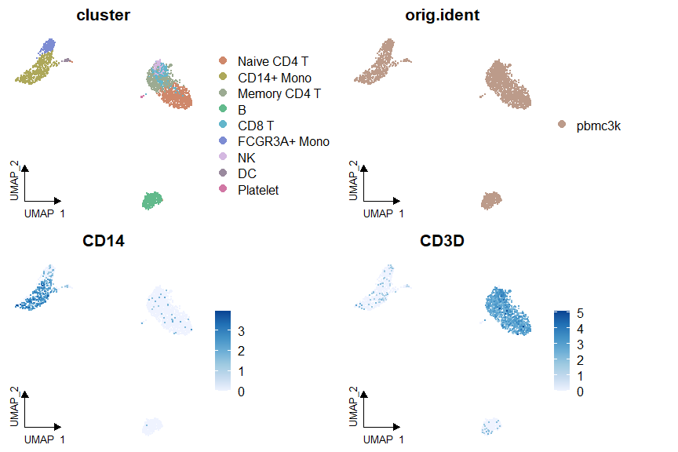

```r
# Add arrows to each subplot
DimPlot2(
  pbmc,
  features = c("cluster", "orig.ident", "CD14", "CD3D"),
  theme = theme_umap_arrows()
)
```

### Simultaneous Display of Three Features on a Dimension Reduction Plot

In `SeuratExtend`, a unique visualization method allows for the simultaneous display of three features on the same dimension reduction plot. The functions `FeaturePlot3` and `FeaturePlot3.grid` employ a color mixing system (either RYB or RGB) to represent three different genes (or other continuous variables). This method uses the principles of color mixing to quantitatively display the expression levels or intensities of these three features in each cell.

#### RYB and RGB Color Systems

In the RGB system, black represents no or low expression, and brighter colors indicate higher levels:

[figure not shown]

In the RYB system, white represents no expression, and deeper colors indicate higher expression levels:

[figure not shown]

#### Examples Using RYB and RGB Systems

Here’s how to display three markers using the RYB system, with red for CD3D, yellow for CD14, and blue for CD79A:

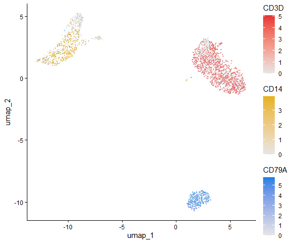

```r
FeaturePlot3(pbmc, color = "ryb", feature.1 = "CD3D", feature.2 = "CD14", feature.3 = "CD79A", pt.size = 0.5)
```

For the RGB system, with red for CD3D, green for CD14, and blue for CD79A:

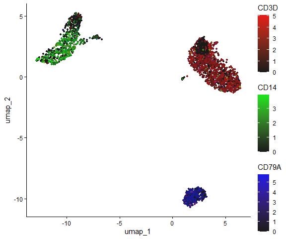

```r
FeaturePlot3(pbmc, color = "rgb", feature.1 = "CD3D", feature.2 = "CD14", feature.3 = "CD79A", pt.size = 1)
```

#### Using Dark Theme (New in v1.2.0)

For improved visualization in presentations or in low-light environments, you can use the dark theme option:

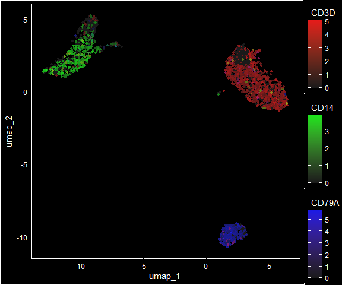

```r
FeaturePlot3(
  pbmc,
  color = "rgb",
  feature.1 = "CD3D",
  feature.2 = "CD14",
  feature.3 = "CD79A",
  pt.size = 1,
  dark.theme = TRUE
)
```

This dark theme provides better contrast for visualizing gene expression patterns, particularly when using the RGB color system where brighter colors represent higher expression levels.

#### Batch Visualization with `FeaturePlot3.grid`

```r
DefaultAssay(pbmc) <- "RNA"

genes <- c("CD3D", "CD14", "CD79A", "FCGR3A", "LYZ")
setdiff(genes, rownames(pbmc))  # should print character(0)
```

```
## character(0)
```

```r
DefaultAssay(pbmc)
```

```
## [1] "RNA"
```

```r
sapply(c("CD3D","CD14","CD79A","FCGR3A","LYZ"), \(g) g %in% rownames(pbmc))
```

```
##   CD3D   CD14  CD79A FCGR3A    LYZ
##   TRUE   TRUE   TRUE   TRUE   TRUE
```

```r
sessionInfo()$otherPkgs[c("Seurat","SeuratObject","SeuratExtend")]
```

[output not shown]

[output cut: 221 more lines]

[output not shown]

```r
DefaultAssay(pbmc)
```

```
## [1] "RNA"
```

```r
setdiff(c("CD3D","CD14","CD79A","FCGR3A","LYZ","NKG7"), rownames(pbmc))
```

```
## character(0)
```

[figure not shown]

```r
p1 <- FeaturePlot3(pbmc, feature.1 = "CD3D", feature.2 = "CD14", feature.3 = "CD79A",
                   color = "ryb", pt.size = 0.5)

p2 <- FeaturePlot3(pbmc, feature.1 = "FCGR3A", feature.2 = "LYZ", feature.3 = "RPLP0",
                   color = "ryb", pt.size = 0.5)

p1 + p2 # patchwork
```

```r
library(patchwork)
```

```
## ℹ Adding new coordinate system, which will replace the existing one.
```

```
## ℹ Adding new coordinate system, which will replace the existing one.
```

[figure not shown]

```r
library(grid)    # for unit()

# collect legends, move to bottom, add margins, prevent clipping
(p1 + p2) +
  plot_layout(guides = "collect") &
  theme(
    legend.position = "bottom",
    legend.justification = c(0.5, 0),
    legend.box.margin = margin(t = 4, r = 20, b = 12, l = 20),
    legend.key.width  = unit(12, "mm"),
    legend.key.height = unit(4,  "mm"),
    plot.margin = margin(t = 10, r = 30, b = 30, l = 10)
  ) &
  coord_cartesian(clip = "off")
```

```r
# FeaturePlot3.grid(
#   pbmc,
#   features = c("CD3D","CD14","CD79A",   # panel 1
#                "FCGR3A","LYZ","RPLP0"), # panel 2 (unique 3rd)
#   color = "rgb",
#   pt.size = 0.5
# )
```

```r
# FeaturePlot3.grid(
#   pbmc,
#   features = c("CD3D", "CD14", "CD79A", "FCGR3A", "RPLP0", "LYZ"),
#   color = "rgb",
#   pt.size = 1,
#   dark.theme = TRUE,
#   legend = TRUE
# )
```

#### Tips on Point Size

The background is usually white, so the choice of color system and point size can significantly affect visual perception. In the RYB system, where higher expression results in darker colors, a smaller `pt.size` is preferable to prevent overlapping points. In contrast, in the RGB system, higher expressions result in lighter colors, potentially leading to visibility issues for highly expressed cells that may blend into the white background. Here, a larger `pt.size` is recommended so that the darker, low-expression points can form a “background” to highlight the lighter, high-expression points.

## Generate a Heatmap Plot

### Introduction

The `Heatmap` function provides a flexible and comprehensive way to visualize matrices, especially those produced by the `CalcStats` function. While heatmaps are excellent for visualizing overall patterns across multiple groups and features, they represent average expression levels through color intensity.

**Note:** Starting from v1.1.0, the default color scheme has changed from `c(low = muted("blue"), mid = "white", high = muted("red"))` to `"BuRd"`. This change was made to provide more vibrant visualization using RColorBrewer palettes. To revert to the previous color scheme, simply set `color_scheme = c(low = muted("blue"), mid = "white", high = muted("red"))`.

### Basic Usage

First, let’s generate a sample matrix using the `CalcStats` function:

```r
# Calculate z-scores for variable features
genes <- VariableFeatures(pbmc)
toplot <- CalcStats(pbmc, features = genes, method = "zscore", order = "p", n = 5)
```

> Calculate Matrix Statistics Grouped by Clusters Computes various statistics (mean, median, zscore, tscore, etc.) on a matrix, grouped by clusters.

> CalcStats(object, …)

Now, we can produce a basic heatmap:

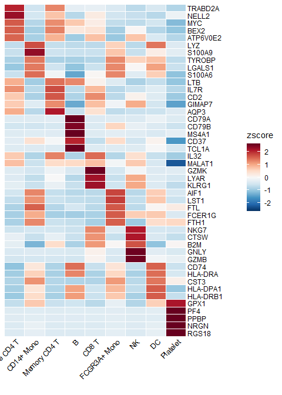

```r
# Create a basic heatmap
Heatmap(toplot, lab_fill = "zscore")
```

### Adjusting Color Schemes

The `color_scheme` parameter allows for flexibility in visualizing data. Here are some ways to change the color theme of your heatmap:

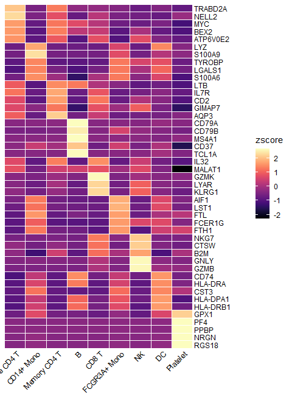

```r
# Viridis-A theme
Heatmap(toplot, lab_fill = "zscore", color_scheme = "A")
```

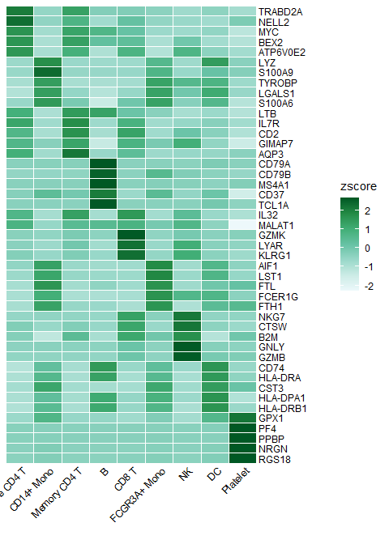

```r
# White - blue - dark green
Heatmap(toplot, lab_fill = "zscore", color_scheme = "BuGn")
```

For detailed information on color customization, refer to the Explore Color Functions section.

### Modifying Axis and Labels

Sometimes, the first name on the x-axis might be too long and exceed the left boundary of the plot. To prevent this issue and ensure all labels are fully visible, you can increase the space on the left side of the plot by adjusting the `plot.margin` parameter. For example, to add more space, you can specify a larger value for the left margin (`l`) like this:

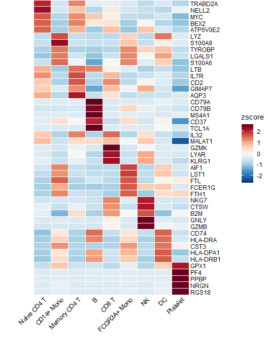

```r
Heatmap(toplot, lab_fill = "zscore", plot.margin = margin(l = 50))
```

For dense matrices with many features, you might want to show only a subset of gene names:

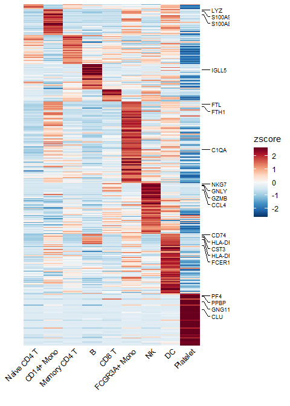

```r
toplot2 <- CalcStats(pbmc, features = genes[1:500], method = "zscore", order = "p")
Heatmap(toplot2, lab_fill = "zscore", feature_text_subset = genes[1:20], expand_limits_x = c(-0.5, 11))
```

### Faceting the Heatmap

You can split the heatmap based on gene groups:

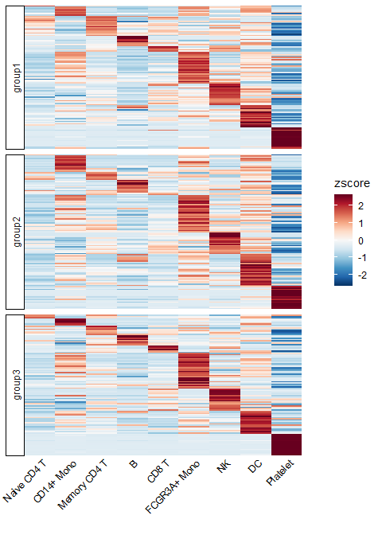

```r
gene_groups <- sample(c("group1", "group2", "group3"), nrow(toplot2), replace = TRUE)
Heatmap(toplot2, lab_fill = "zscore", facet_row = gene_groups) +
  theme(axis.text.y = element_blank())
```

## Create Enhanced Dot Plots (New in v1.1.0)

### Introduction

While heatmaps are excellent for visualizing overall patterns, dot plots offer a complementary visualization that combines two key pieces of information:

1. The percentage of cells expressing each feature (represented by dot size)
2. The average expression level in expressing cells (represented by color intensity)

This dual representation can provide more detailed insights than a standard heatmap, particularly when expression patterns vary between cell populations.

### Basic Usage

Let’s create a basic dot plot for some variable features:

```r
# Select some variable features
genes <- VariableFeatures(pbmc)[1:10]
genes
```

```
##  [1] "PPBP"   "LYZ"    "S100A9" "IGLL5"  "GNLY"   "FTL"    "PF4"    "FTH1"
##  [9] "GNG11"  "S100A8"
```

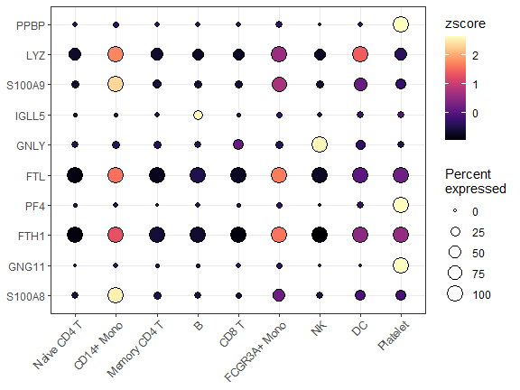

```r
DotPlot2(pbmc, features = genes)
```

### Grouped Features

You can organize features into groups for clearer visualization:

```r
# Create grouped features
grouped_features <- list(
  "B_cell_markers" = c("MS4A1", "CD79A"),
  "T_cell_markers" = c("CD3D", "CD8A", "IL7R"),
  "Myeloid_markers" = c("CD14", "FCGR3A", "S100A8")
)
grouped_features
```

```
## $B_cell_markers
## [1] "MS4A1" "CD79A"
##
## $T_cell_markers
## [1] "CD3D" "CD8A" "IL7R"
##
## $Myeloid_markers
## [1] "CD14"   "FCGR3A" "S100A8"
```

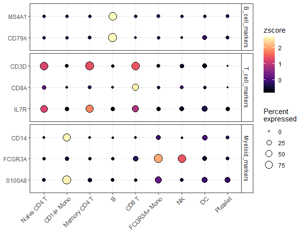

```r
DotPlot2(pbmc, features = grouped_features)
```

### Split Visualization

You can split the visualization by a metadata column to compare expression patterns across different conditions:

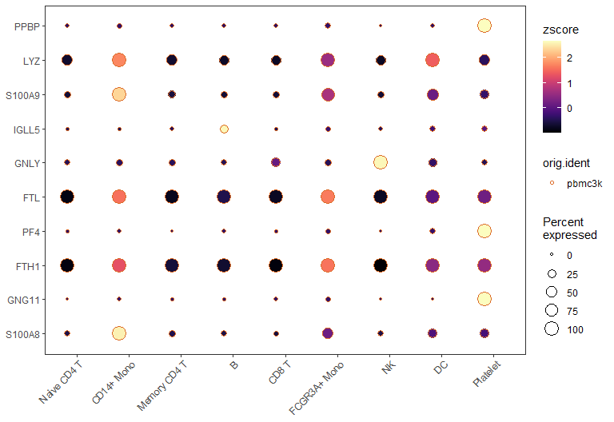

```r
# Basic split visualization
DotPlot2(
  pbmc,
  features = genes,
  group.by = "cluster",
  split.by = "orig.ident",
  show_grid = FALSE
)
```

### Alternative Split Visualization

The split groups can be represented either by border colors (default) or by dot colors:

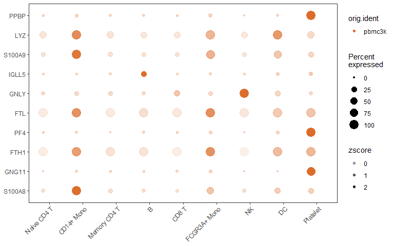

```r
# Using colors instead of borders for split groups
DotPlot2(
  pbmc,
  features = genes,
  group.by = "cluster",
  split.by = "orig.ident",
  split.by.method = "color",
  show_grid = FALSE
)
```

### Customizing Appearance

You can customize various aspects of the plot, including color schemes, dot sizes, and grid lines:

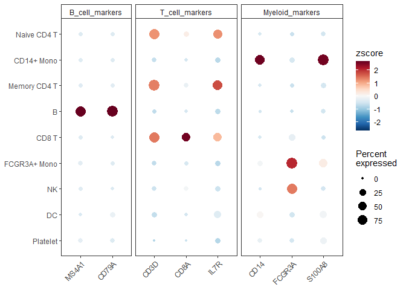

```r
DotPlot2(
  pbmc,
  features = grouped_features,
  color_scheme = "BuRd",
  border = FALSE,
  # Remove dot borders
  show_grid = FALSE,
  # Remove grid lines
  flip = TRUE
)          # Flip coordinates
```

## Create an Enhanced Violin Plot

### Introduction

The `VlnPlot2` function offers a revamped version of the traditional violin plot, designed to be more space-efficient while introducing additional visualization features. Unlike the original `VlnPlot` in Seurat, this enhanced version integrates boxplots, statistical annotations, and greater flexibility in plot presentation.

### Basic Usage

Let’s start with some common gene markers:

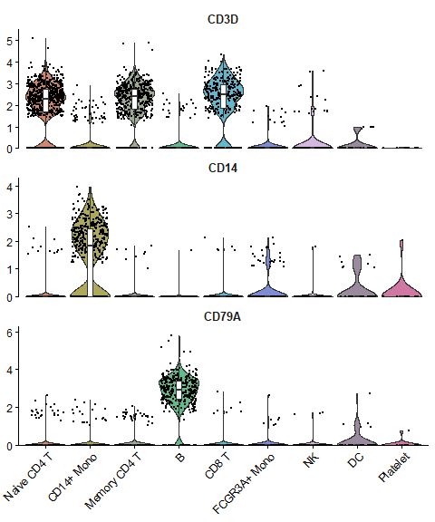

```r
library(Seurat)
library(SeuratExtend)

genes <- c("CD3D","CD14","CD79A")
VlnPlot2(pbmc, features = genes, ncol = 1)
```

### Customizing Plot Elements

You can create different variations of the plot by adjusting its components. For instance, you might want to show only the box plot with quasirandom point distribution:

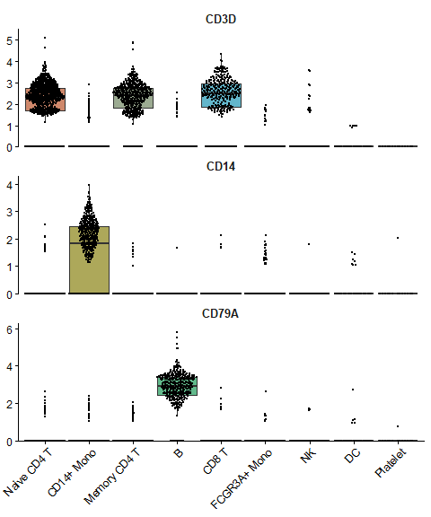

```r
VlnPlot2(pbmc, features = genes, violin = FALSE, pt.style = "quasirandom", ncol = 1)
```

### Managing Point Display

For cleaner visualization, you can hide individual points while still showing outliers:

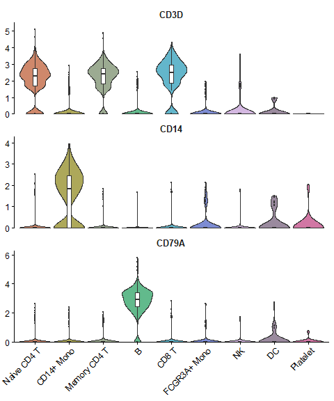

```r
VlnPlot2(pbmc, features = genes, pt = FALSE, ncol = 1)
```

Or hide both points and outliers for a minimal appearance:

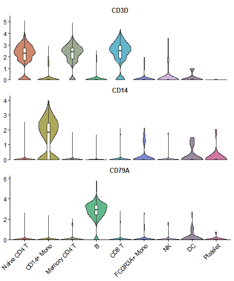

```r
VlnPlot2(pbmc, features = genes, pt = FALSE, hide.outlier = TRUE, ncol = 1)
```